# BellaBeat

George.B

2022-11-20

# summary

## 1.The Business Project

- The task is to look out for trend on how people use the company smart devices and these insights can be used by BellaBeat.

### Working with Rstudio.

Settings the Rstudio and loading all necessary package to work with and then importing the BellaBeat dataset into my Rstudio.

```r
 library(tidyverse)
 library(dplyr)
 library(tidyr)
 library(here)
```

```r
 library(ggplot2)
 library(colorspace)
 library(readr)
```

### importing the dataset.

```r
library(readr)
dailyActivity_merged <- read_csv("C:/Users/pc/Desktop/Fitabase Data 4.12.16-5.12.16/dailyActivity_merged.csv")
View(dailyActivity_merged)
sleepDay_merged <- read_csv("C:/Users/pc/Desktop/Fitabase Data 4.12.16-5.12.16/sleepDay_merged.csv")
View(sleepDay_merged)
weightLogInfo_merged <- read_csv("C:/Users/pc/Desktop/Fitabase Data 4.12.16-5.12.16/weightLogInfo_merged.csv")
View(weightLogInfo_merged)
```

### Let do some quick summary check of the data columns.

```r
str(dailyActivity_merged)
```

```
## spc_tbl_ [940 × 15] (S3: spec_tbl_df/tbl_df/tbl/data.frame)
##  $ Id                      : num [1:940] 1.5e+09 1.5e+09 1.5e+09 1.5e+09 1.5e+09 ...
##  $ ActivityDate            : chr [1:940] "4/12/2016" "4/13/2016" "4/14/2016" "4/15/2016" ...
##  $ TotalSteps              : num [1:940] 13162 10735 10460 9762 12669 ...
##  $ TotalDistance           : num [1:940] 8.5 6.97 6.74 6.28 8.16 ...
##  $ TrackerDistance         : num [1:940] 8.5 6.97 6.74 6.28 8.16 ...
##  $ LoggedActivitiesDistance: num [1:940] 0 0 0 0 0 0 0 0 0 0 ...
##  $ VeryActiveDistance      : num [1:940] 1.88 1.57 2.44 2.14 2.71 ...
##  $ ModeratelyActiveDistance: num [1:940] 0.55 0.69 0.4 1.26 0.41 ...
##  $ LightActiveDistance     : num [1:940] 6.06 4.71 3.91 2.83 5.04 ...
##  $ SedentaryActiveDistance : num [1:940] 0 0 0 0 0 0 0 0 0 0 ...
##  $ VeryActiveMinutes       : num [1:940] 25 21 30 29 36 38 42 50 28 19 ...
##  $ FairlyActiveMinutes     : num [1:940] 13 19 11 34 10 20 16 31 12 8 ...
##  $ LightlyActiveMinutes    : num [1:940] 328 217 181 209 221 164 233 264 205 211 ...
##  $ SedentaryMinutes        : num [1:940] 728 776 1218 726 773 ...
##  $ Calories                : num [1:940] 1985 1797 1776 1745 1863 ...
##  - attr(*, "spec")=
##   .. cols(
##   ..   Id = col_double(),
##   ..   ActivityDate = col_character(),
##   ..   TotalSteps = col_double(),
##   ..   TotalDistance = col_double(),
##   ..   TrackerDistance = col_double(),
##   ..   LoggedActivitiesDistance = col_double(),
##   ..   VeryActiveDistance = col_double(),
##   ..   ModeratelyActiveDistance = col_double(),
##   ..   LightActiveDistance = col_double(),
##   ..   SedentaryActiveDistance = col_double(),
##   ..   VeryActiveMinutes = col_double(),
##   ..   FairlyActiveMinutes = col_double(),
##   ..   LightlyActiveMinutes = col_double(),
##   ..   SedentaryMinutes = col_double(),
##   ..   Calories = col_double()
##   .. )
##  - attr(*, "problems")=<externalptr>
```

```r
colnames(dailyActivity_merged)
```

```
##  [1] "Id"                       "ActivityDate"
##  [3] "TotalSteps"               "TotalDistance"
##  [5] "TrackerDistance"          "LoggedActivitiesDistance"
##  [7] "VeryActiveDistance"       "ModeratelyActiveDistance"
##  [9] "LightActiveDistance"      "SedentaryActiveDistance"
## [11] "VeryActiveMinutes"        "FairlyActiveMinutes"
## [13] "LightlyActiveMinutes"     "SedentaryMinutes"
## [15] "Calories"
```

```r
str(sleepDay_merged)
```

```
## spc_tbl_ [413 × 5] (S3: spec_tbl_df/tbl_df/tbl/data.frame)
##  $ Id                : num [1:413] 1.5e+09 1.5e+09 1.5e+09 1.5e+09 1.5e+09 ...
##  $ SleepDay          : chr [1:413] "4/12/2016 12:00:00 AM" "4/13/2016 12:00:00 AM" "4/15/2016 12:00:00 AM" "4/16/2016 12:00:00 AM" ...
##  $ TotalSleepRecords : num [1:413] 1 2 1 2 1 1 1 1 1 1 ...
##  $ TotalMinutesAsleep: num [1:413] 327 384 412 340 700 304 360 325 361 430 ...
##  $ TotalTimeInBed    : num [1:413] 346 407 442 367 712 320 377 364 384 449 ...
##  - attr(*, "spec")=
##   .. cols(
##   ..   Id = col_double(),
##   ..   SleepDay = col_character(),
##   ..   TotalSleepRecords = col_double(),
##   ..   TotalMinutesAsleep = col_double(),
##   ..   TotalTimeInBed = col_double()
##   .. )
##  - attr(*, "problems")=<externalptr>
```

```r
colnames(sleepDay_merged)
```

```
## [1] "Id"                 "SleepDay"           "TotalSleepRecords"
## [4] "TotalMinutesAsleep" "TotalTimeInBed"
```

```r
str(weightLogInfo_merged)
```

```
## spc_tbl_ [67 × 8] (S3: spec_tbl_df/tbl_df/tbl/data.frame)
##  $ Id            : num [1:67] 1.50e+09 1.50e+09 1.93e+09 2.87e+09 2.87e+09 ...
##  $ Date          : chr [1:67] "5/2/2016 11:59:59 PM" "5/3/2016 11:59:59 PM" "4/13/2016 1:08:52 AM" "4/21/2016 11:59:59 PM" ...
##  $ WeightKg      : num [1:67] 52.6 52.6 133.5 56.7 57.3 ...
##  $ WeightPounds  : num [1:67] 116 116 294 125 126 ...
##  $ Fat           : num [1:67] 22 NA NA NA NA 25 NA NA NA NA ...
##  $ BMI           : num [1:67] 22.6 22.6 47.5 21.5 21.7 ...
##  $ IsManualReport: logi [1:67] TRUE TRUE FALSE TRUE TRUE TRUE ...
##  $ LogId         : num [1:67] 1.46e+12 1.46e+12 1.46e+12 1.46e+12 1.46e+12 ...
##  - attr(*, "spec")=
##   .. cols(
##   ..   Id = col_double(),
##   ..   Date = col_character(),
##   ..   WeightKg = col_double(),
##   ..   WeightPounds = col_double(),
##   ..   Fat = col_double(),
##   ..   BMI = col_double(),
##   ..   IsManualReport = col_logical(),
##   ..   LogId = col_double()
##   .. )
##  - attr(*, "problems")=<externalptr>
```

```r
colnames(weightLogInfo_merged)
```

```
## [1] "Id"             "Date"           "WeightKg"       "WeightPounds"
## [5] "Fat"            "BMI"            "IsManualReport" "LogId"
```

### Descriptive Analyses will now beging.

selecting and cleaning the data to wrangle. In these case i will be selecting some vital columns from thr dailyActivity_merge dataset to work with.

```r
dailyActivity_merged2 <- dailyActivity_merged %>%
  select(TotalDistance, VeryActiveDistance, ModeratelyActiveDistance, LightActiveDistance, Calories) %>%
  drop_na() %>%
  summarise(TotalDistance, VeryActiveDistance, ModeratelyActiveDistance, LightActiveDistance, Calories)
```

### visual representation

```r
dailyActive_merge_pattern <- dailyActivity_merged2 %>%
  group_by(TotalDistance, Calories) %>%
  drop_na() %>%
  summarise(TotalDistance, Calories) %>%
  arrange(TotalDistance, Calories)
```

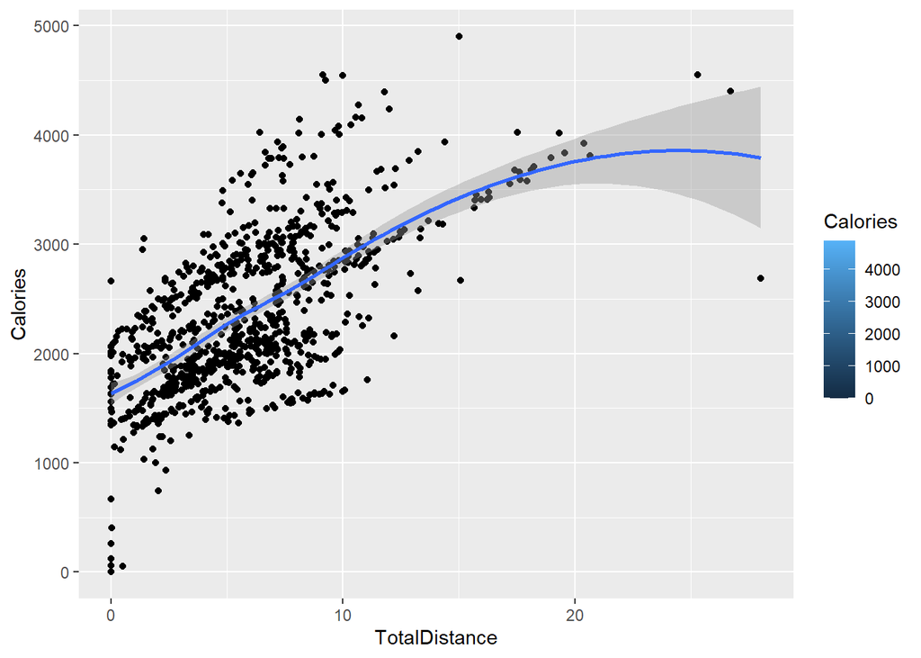

```r
ggplot(data=dailyActive_merge_pattern)+
  geom_point(mapping=aes(x=TotalDistance, y=Calories, fill=Calories))+
  geom_smooth(mapping=aes(x=TotalDistance, y=Calories, fill=Calories))
```

The graph about shows that the more distance covered by a user the more calories they burn out of their body, and the lesser distance covered the smaller the calories the user burn out of they body.

### active records

here i am analysing the very active distance covered by each user against the time they use in covering that distance.

```r
dailyActivity_merged_veryactive <- dailyActivity_merged %>%
  group_by(VeryActiveDistance, VeryActiveMinutes) %>%
  drop_na() %>%
  summarise(VeryActiveDistance, VeryActiveMinutes) %>%
  arrange(VeryActiveDistance, VeryActiveMinutes)
```

[output not shown]

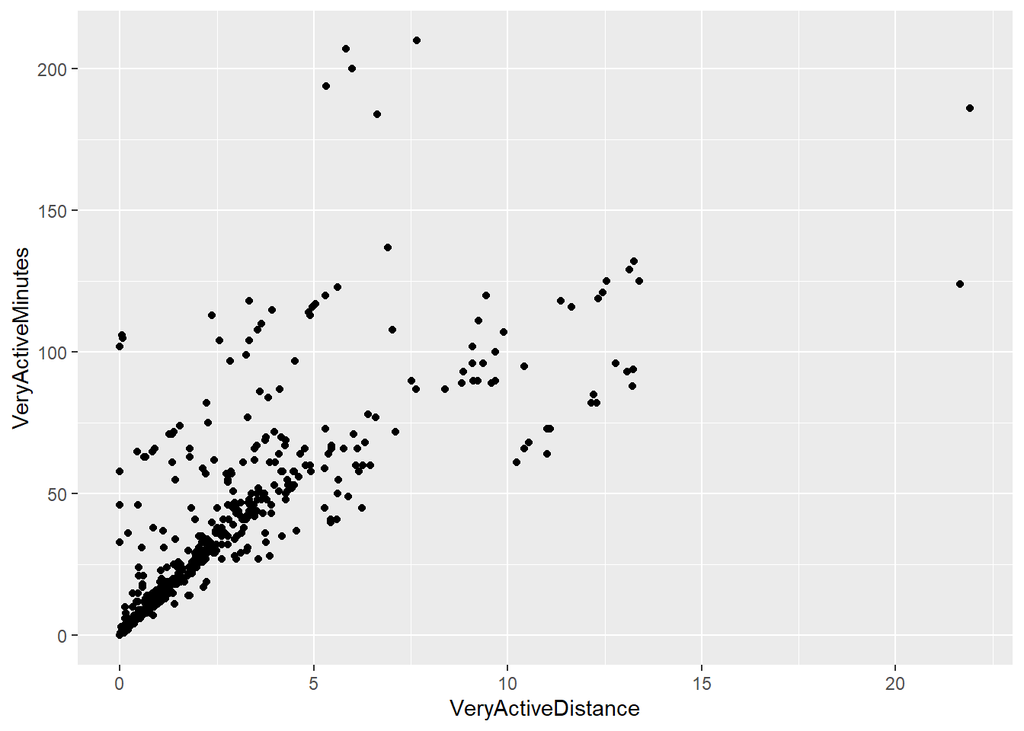

```r
ggplot(data=dailyActivity_merged_veryactive)+
  geom_point(mapping=aes(x=VeryActiveDistance, y=VeryActiveMinutes))
```

```r
View(dailyActivity_merged_veryactive)
View(dailyActivity_merged_veryactive)
```

### Sleepday analyses

time to wrangle the second dataset on my workspace. firstly i want to select, sort and summarise the particular columns to analyse.

```r
sleepday_01 <- sleepDay_merged %>%
  separate(SleepDay, into = c('Date', 'Time'), sep= ' ')
print(sleepday_01)
```

```
## # A tibble: 413 × 6
##            Id Date      Time     TotalSleepRecords TotalMinutesAsleep TotalTim…¹
##         <dbl> <chr>     <chr>                <dbl>              <dbl>      <dbl>
##  1 1503960366 4/12/2016 12:00:00                 1                327        346
##  2 1503960366 4/13/2016 12:00:00                 2                384        407
##  3 1503960366 4/15/2016 12:00:00                 1                412        442
##  4 1503960366 4/16/2016 12:00:00                 2                340        367
##  5 1503960366 4/17/2016 12:00:00                 1                700        712
##  6 1503960366 4/19/2016 12:00:00                 1                304        320
##  7 1503960366 4/20/2016 12:00:00                 1                360        377
##  8 1503960366 4/21/2016 12:00:00                 1                325        364
##  9 1503960366 4/23/2016 12:00:00                 1                361        384
## 10 1503960366 4/24/2016 12:00:00                 1                430        449
## # … with 403 more rows, and abbreviated variable name ¹TotalTimeInBed
```

```r
total_s_t <- sleepday_01%>%
  group_by(TotalSleepRecords, TotalMinutesAsleep, TotalTimeInBed) %>%
  drop_na() %>%
  summarise(TotalSleepRecords, TotalMinutesAsleep, TotalTimeInBed)
```

[output not shown]

```r
print(total_s_t)
```

```
## # A tibble: 413 × 3
## # Groups:   TotalSleepRecords, TotalMinutesAsleep, TotalTimeInBed [407]
##    TotalSleepRecords TotalMinutesAsleep TotalTimeInBed
##                <dbl>              <dbl>          <dbl>
##  1                 1                 58             61
##  2                 1                 59             65
##  3                 1                 61             69
##  4                 1                 62             65
##  5                 1                 74             75
##  6                 1                 74             78
##  7                 1                 77             77
##  8                 1                 79             82
##  9                 1                 82             85
## 10                 1                 98            107
## # … with 403 more rows
```

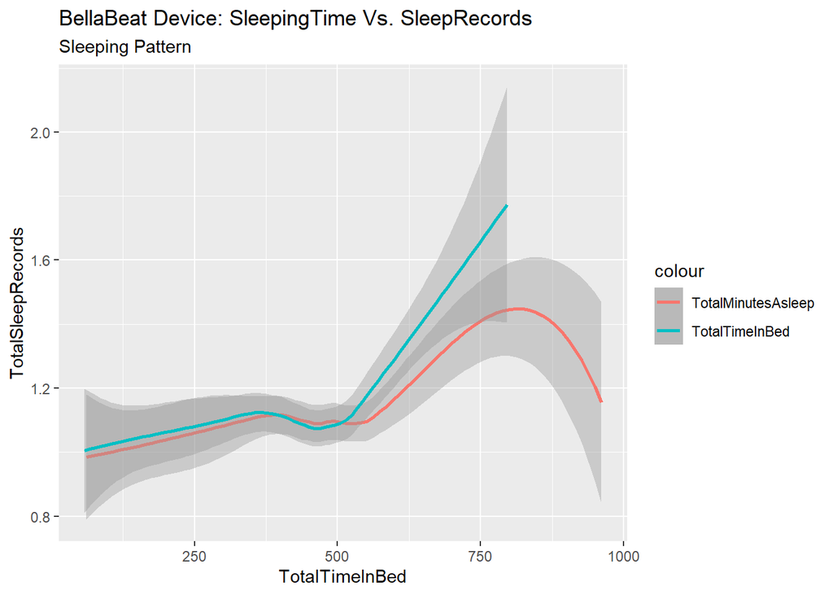

```r
ggplot(data=sleepday_01)+
  geom_smooth(mapping=aes(x=TotalTimeInBed, y=TotalSleepRecords, group=1, color='TotalMinutesAsleep'))+
  geom_smooth(mapping=aes(x=TotalMinutesAsleep, y=TotalSleepRecords, group=2, color='TotalTimeInBed'))+
  labs(title = "BellaBeat Device: SleepingTime Vs. SleepRecords", subtitle = "Sleeping Pattern")
```

### weight analyses

here i will be analysing the weight of the users against their body mass index(BMI)

```r
weightactivity <- weightLogInfo_merged %>%
  select(WeightPounds, BMI, IsManualReport) %>%
  group_by(WeightPounds, BMI, IsManualReport) %>%
  drop_na() %>%
  summarise(WeightPounds, BMI, IsManualReport) %>%
  arrange(WeightPounds, BMI, IsManualReport)
```

[output not shown]

```r
print(weightactivity)
```

```
## # A tibble: 67 × 3
## # Groups:   WeightPounds, BMI, IsManualReport [36]
##    WeightPounds   BMI IsManualReport
##           <dbl> <dbl> <lgl>
##  1         116.  22.6 TRUE
##  2         116.  22.6 TRUE
##  3         125.  21.5 TRUE
##  4         126.  21.7 TRUE
##  5         134.  23.8 TRUE
##  6         134.  23.8 TRUE
##  7         135.  23.9 TRUE
##  8         135.  23.9 TRUE
##  9         135.  23.9 TRUE
## 10         135.  23.9 TRUE
## # … with 57 more rows
```

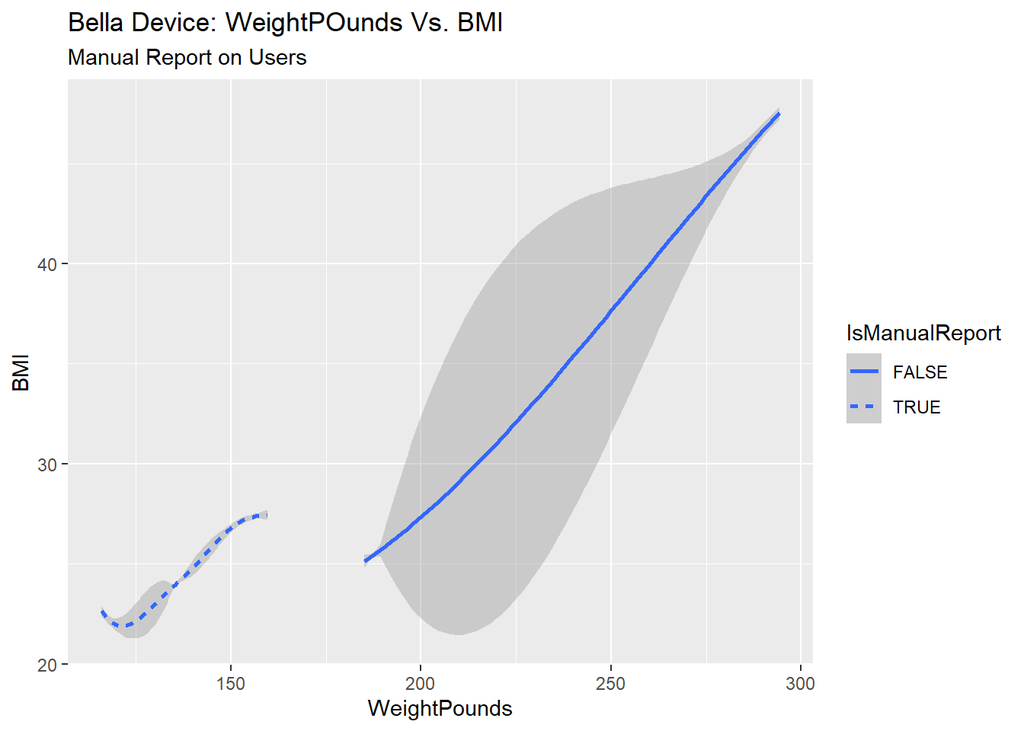

```r
ggplot(data=weightactivity)+
  geom_smooth(mapping = aes(x=WeightPounds, y=BMI, linetype=IsManualReport))+
  labs(title = "Bella Device: WeightPOunds Vs. BMI", subtitle = "Manual Report on Users")
```

this plot showcase a correlation between users weight and their body mass, The TRUE report conforms to the users weighting below 170pounds and having a body mass of less 30, While the FALSE report shows that user who weigh higher most surely have a higher body mass.